# Kriging using (mini)gstlearn - Correction

Emilie Chautru, Mike Pereira, and Thomas Romary

Option Géostatistique 2024

# Preamble

```r
OptCst_defineByKey("ASP",0)
```

## Loading the Meuse dataset

We start by loading the data from the `sp` package. We load two data frames:

- `meuse` is a R dataframe containing metal concentrations measured along the Meuse river in France. It contains the following variables:
  - **x** and **y**: easting and northing (m) coordinates
  - **cadmium**, **copper**, **lead**, **zinc**: topsoil heavy metal concentrations (ppm) (NB: obtained from composite samples **15m x 15m**)
  - **elev**: relative elevation above the river (m)
  - **dist**: distance to the river (normalized between 0 and 1)
  - **om**, **soil**, **lime**: soil characteristics (content of organic matter, type of soil, presence of lime)
  - **ffreq**: flooding frequency class: 1 = once in two years; 2 = once in ten years; 3 = one in 50 years
  - **landuse**: landuse classes
  - **dist.m**: distance to the river (m)
- `meuse.grid` is a R dataframe containing describing a grid covering the Meuse river (and the samples in the `meuse` dataframe). It contains the following variables:
  - **x** and **y**: easting and northing (m) coordinates
  - **dist**: distance to the river (normalized between 0 and 1)
  - **soil**: soil characteristics (content of organic matter, type of soil, presence of lime)
  - **ffreq**: flooding frequency class: 1 = once in two years; 2 = once in ten years; 3 = one in 50 years
  - **part.a, part.b**: arbitrary division of the area in two areas, a and b

```r
library(sp,warn.conflicts = F) # load library
data(meuse) # load data
data(meuse.grid) # load target grid
```

We then add the log concentrations of metals to the `meuse` dataframe, thus creating four new variables: **log_cadmium**, **log_copper**, **log_lead**, **log_zinc**.

```r
## Add log of variables to the dataframe
var_names = c( "cadmium", "copper", "lead", "zinc")
logvar_names=paste0("log_",var_names)
for (i in 1:length(var_names)) {
  meuse[logvar_names[i]]=log(meuse[var_names[i]])
}
## Print the first lines of the dataframe
print(head(meuse))
```

```
##        x      y cadmium copper lead zinc  elev       dist   om ffreq soil lime
## 1 181072 333611    11.7     85  299 1022 7.909 0.00135803 13.6     1    1    1
## 2 181025 333558     8.6     81  277 1141 6.983 0.01222430 14.0     1    1    1
## 3 181165 333537     6.5     68  199  640 7.800 0.10302900 13.0     1    1    1
## 4 181298 333484     2.6     81  116  257 7.655 0.19009400  8.0     1    2    0
## 5 181307 333330     2.8     48  117  269 7.480 0.27709000  8.7     1    2    0
## 6 181390 333260     3.0     61  137  281 7.791 0.36406700  7.8     1    2    0
##   landuse dist.m log_cadmium log_copper log_lead log_zinc
## 1      Ah     50   2.4595888   4.442651 5.700444 6.929517
## 2      Ah     30   2.1517622   4.394449 5.624018 7.039660
## 3      Ah    150   1.8718022   4.219508 5.293305 6.461468
## 4      Ga    270   0.9555114   4.394449 4.753590 5.549076
## 5      Ah    380   1.0296194   3.871201 4.762174 5.594711
## 6      Ga    470   1.0986123   4.110874 4.919981 5.638355
```

# Kriging using R

## Model of variogram

Before implementing a kriging predictor, we need to fix a variogram/covariance model for the variable we study (the log concentration of Cadmium). To do so, we fit on the data a variogram model using *gstlearn*.

1. With gstlearn, adjust an isotropic variogram model (impose an **exponential structure**) to the observations of log concentration of Cadmium. (*Hint: See Practical Session on Variography*)

```r
# Convert the `meuse` dataframe (which containins our observations) into a gstlearn Db object called obsDb
obsDb=dfToDb(meuse,coordnames = c("x","y"))

# Create an experimental omnidirectional variogram (with 20 lags seperated by a distance of 100 m) for the log concentration of Cadmium using the Db obsDb (-> `vario_exp`)
varioexp_iso = vario_exp(obsDb,vname="log_cadmium",nlag=20, dlag=100.)

# Fit a model with an exponential covariance on the experimental variogram (-> `model_fit`)
struct_names=c("EXPONENTIAL")
model_iso=model_fit(varioexp_iso,struct=struct_names)

# Display the fitted  model
model_iso$display()
```

```
##
## Model characteristics
## =====================
## Space dimension              = 2
## Number of variable(s)        = 1
## Number of basic structure(s) = 1
## Number of drift function(s)  = 0
## Number of drift equation(s)  = 0
##
## Covariance Part
## ---------------
## Exponential
## - Sill         =      1.844
## - Range        =    953.782
## - Theo. Range  =    318.380
## Total Sill     =      1.844
## Known Mean(s)     0.000
```

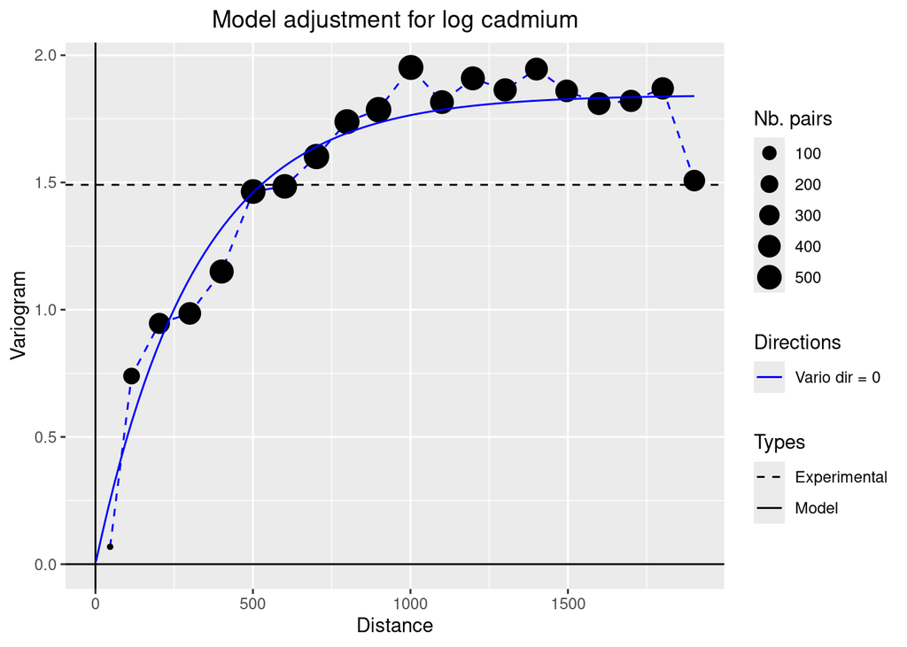

```r
# Plot of the experiment variogram and the fitted model
plot_vario(varioexp_iso,model = model_iso,pairDisplay = "size", title="Model adjustment for log cadmium")
```

Let us extract the scale and sill parameters of the variogram we just fitted on the data.

```r
## Extract scale
model_scale=model_getScales(model_iso)[1]
## Extract sill
model_sill = model_getSills(model_iso)[1,1,1]
```

2. Implement a function to evaluate for a given lag the covariance of the model we just fitted on the data (using the parameters `model_scale` and `model_sill` extracted above).

```r
## Covariance function
modelCov_exp <- function(h){
  # returns the value of exponential covariance at lag h
  model_sill*exp(-(h/model_scale))
}
```

## Simple kriging (using R functions only)

We now implement the simple kriging estimate and the kriging error standard deviation (on a unique neighborhood) to predict the log concentration of Cadmium on the points defined in `meuse.grid`.

1. Build a dataframe `obsData` containing the coordinates of the observations from the dataframe `meuse`, along with the measured log concentration of Cadmium. Similarly, build a dataframe `targetData` containing the coordinates of the points in the dataframe `meuse.grid`. (*(Hint: The command `df[Vector_Of_Variable_Names])` extracts from a dataframe `df` the variables specified in `Vector_Of_Variable_Names` and exports it as a new dataframe.*)

```r
## Data matrix
obsData = meuse[c('x','y','log_cadmium')]
print(head(obsData))
```

```
##        x      y log_cadmium
## 1 181072 333611   2.4595888
## 2 181025 333558   2.1517622
## 3 181165 333537   1.8718022
## 4 181298 333484   0.9555114
## 5 181307 333330   1.0296194
## 6 181390 333260   1.0986123
```

```r
## Target matrix
targetData = meuse.grid[c('x','y')]
print(head(targetData))
```

```
##        x      y
## 1 181180 333740
## 2 181140 333700
## 3 181180 333700
## 4 181220 333700
## 5 181100 333660
## 6 181140 333660
```

2. Compute the mean of the log concentration of Cadmium. (*(Hint: The command `df$Name_Of_A_Variable` extracts the variable `Name_Of_A_Variable` from a dataframe `df` and exports it as a vector.*)

```r
## Mean of observations
mean_log_cadmium = mean(obsData$log_cadmium)
mean_log_cadmium
```

```
## [1] 0.5610659
```

3. Build the matrices of covariance values between pairs of data points and between data points and target points by filling the following code. *(Hint: The function `outer` can be used to compute a matrix containing the distance between pairs of points: if v1 and v2 are two vectors of size n, then `outer(v1,v2,"-")` returns the n x n matrix with entries `v1[i]-v[j]` (for i,j ).)*

```r
## Distance matrix between every pair of observation points
distObsObs = sqrt(outer(obsData$x, obsData$x, "-")^2 + outer(obsData$y, obsData$y, "-")^2)

## Corresponding covariance matrix (Apply the covariance function to the distance matrix)
covObsObs  = modelCov_exp(distObsObs)

## Distance matrix between every pair  (observation point, target point)
distObsTarget = sqrt(outer(obsData$x, targetData$x, "-")^2 + outer(obsData$y, targetData$y, "-")^2)

## Corresponding covariance matrix (Apply the covariance function to the distance matrix)
covObsTarget = modelCov_exp(distObsTarget)
```

4. Build the simple kriging prediction, on the points `targetData`, of the log concentration of Cadmium observed in `obsData`. In particular, use the mean of the log concentration of Cadmium as the known mean of the predictor. Then, compute the associated kriging standard-deviation.

```r
## Compute simple kriging weights
SKweights = solve(covObsObs, covObsTarget)

## Simple kriging estimate
SKestim = mean_log_cadmium + t(SKweights) %*% (obsData$log_cadmium - mean_log_cadmium)

## Kriging variance
SKvar = model_sill - apply(SKweights * covObsTarget, 2, sum)
#SKvar=cov-diag(t(SKweights)%*%covTargetGrid) # equivalent to above but numerically less efficient

## Kriging standard deviation
SKsd = sqrt(SKvar)
```

Let us plot our predictor and its standard deviation.

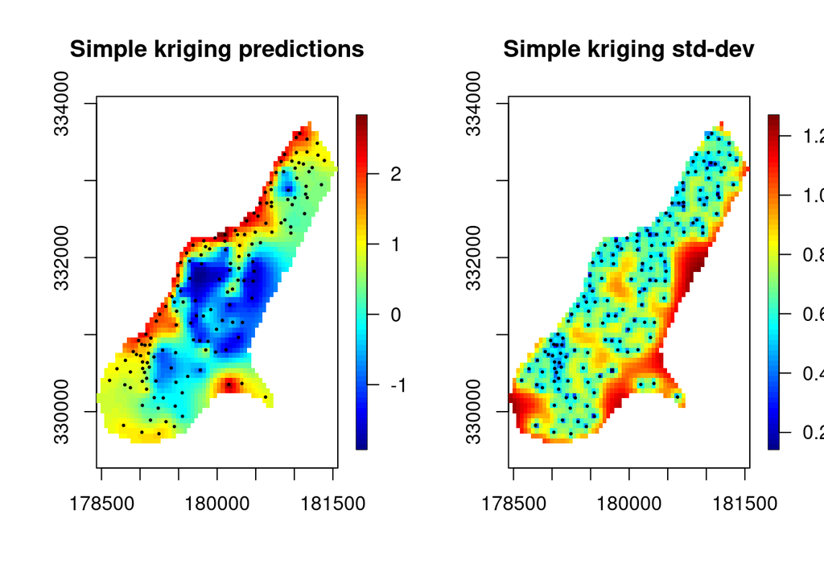

```r
## Plot the results side by side
par(mfrow=c(1,2)) #<- To create an array of plots
# Plot of the kriging predictions using `quilt.plot` from the `fields` package
quilt.plot(targetData$x, targetData$y, SKestim, asp=1,main="Simple kriging predictions")
points(obsData$x,obsData$y,pch=19,cex=0.25)
# Plot of the kriging standard deviations using `quilt.plot` from the `fields` package
quilt.plot(targetData$x, targetData$y, SKsd, asp=1,main="Simple kriging std-dev")
points(obsData$x,obsData$y,pch=19,cex=0.25)
```

```r
par(mfrow=c(1,1)) #<- To revert to a single plot
```

# Kriging using gstlearn

## Simple kriging (Unique neighborhood)

We now show how to use *gstlearn* to compute kriging predictors. The first thing we need to do is to convert our R dataframe `meuse` and `meuse.grid` into *gstlearn* Db objects.

```r
## Create Db containing the data from the `meuse` dataframe (Already done before)
obsDb=dfToDb(meuse,coordnames = c("x","y"))
obsDb$display()
```

```
##
## Data Base Characteristics
## =========================
##
## Data Base Summary
## -----------------
## File is organized as a set of isolated points
## Space dimension              = 2
## Number of Columns            = 18
## Total number of samples      = 155
##
## Variables
## ---------
## Column = 0 - Name = x - Locator = x1
## Column = 1 - Name = y - Locator = x2
## Column = 2 - Name = cadmium - Locator = NA
## Column = 3 - Name = copper - Locator = NA
## Column = 4 - Name = lead - Locator = NA
## Column = 5 - Name = zinc - Locator = NA
## Column = 6 - Name = elev - Locator = NA
## Column = 7 - Name = dist - Locator = NA
## Column = 8 - Name = om - Locator = NA
## Column = 9 - Name = ffreq - Locator = NA
## Column = 10 - Name = soil - Locator = NA
## Column = 11 - Name = lime - Locator = NA
## Column = 12 - Name = landuse - Locator = NA
## Column = 13 - Name = dist.m - Locator = NA
## Column = 14 - Name = log_cadmium - Locator = NA
## Column = 15 - Name = log_copper - Locator = NA
## Column = 16 - Name = log_lead - Locator = NA
## Column = 17 - Name = log_zinc - Locator = NA
```

```r
# Convert `meuse.grid` from R dataframe to gstlearn grid database (DbGrid)
targetDb = dfToDbGrid(meuse.grid,coordnames = c('x','y'))
targetDb$display()
```

```
##
## Data Base Grid Characteristics
## ==============================
##
## Data Base Summary
## -----------------
## File is organized as a regular grid
## Space dimension              = 2
## Number of Columns            = 8
## Total number of samples      = 8112
## Number of active samples     = 3103
##
## Grid characteristics:
## ---------------------
## Origin : 178460.000329620.000
## Mesh   :     40.000    40.000
## Number :         78       104
##
## Variables
## ---------
## Column = 0 - Name = x - Locator = x1
## Column = 1 - Name = y - Locator = x2
## Column = 2 - Name = part.a - Locator = NA
## Column = 3 - Name = part.b - Locator = NA
## Column = 4 - Name = dist - Locator = NA
## Column = 5 - Name = soil - Locator = NA
## Column = 6 - Name = ffreq - Locator = NA
## Column = 7 - Name = Sel_Not_NA - Locator = sel
```

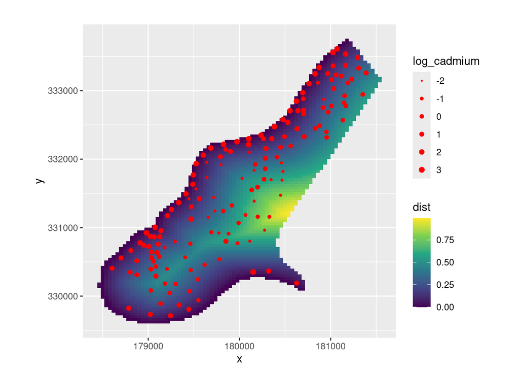

```r
# Plot the distance covariate
p=dbplot_grid(targetDb, color='dist')
dbplot_point(obsDb,size="log_cadmium",
             sizeRange = c(0.25,2), pointColor = "red",
             title = "Distance to the river Meuse and data locations", xlab = "Easting (m)", ylab = "Northing (m)",
             add=p)
```

1. Compute a simple kriging prediction on the points in `targetDb` using the data in `obsDb` and the model `model_iso` fitted in the previous section. Plot the results (prediction and standard deviation of kriging error) and compare them to the results obtained in the previous part (using `R` only). *(Hint: Use the function `minikriging` and set the prefix to “SK_iso”)*

```r
## Simple kriging using gstlearn
minikriging(obsDb, targetDb, vname = "log_cadmium",
            model = model_iso,
            type = "simple", mean = mean_log_cadmium,  prefix = "SK_iso",
            std = TRUE)
```

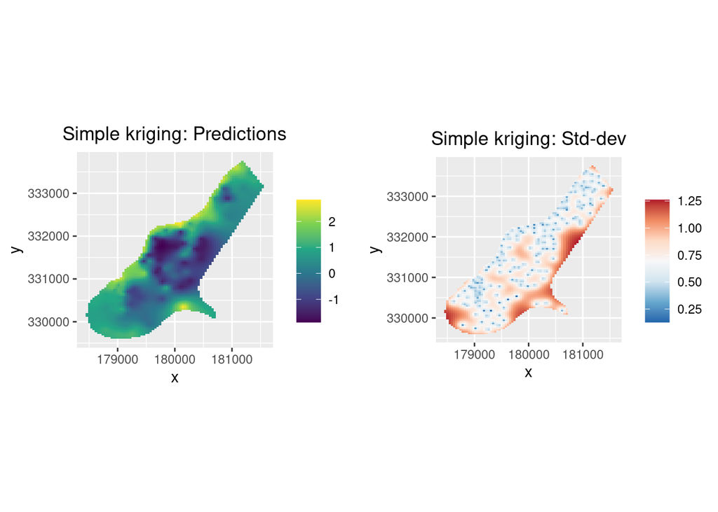

```r
## Plot kriging estimate (-> cf. `dbplot_grid`)
p1=dbplot_grid(targetDb, color='SK_iso.log_cadmium.estim',
               title='Simple kriging: Predictions',legendTitle = "")

## Plot kriging stdev
p2=dbplot_grid(targetDb, color='SK_iso.log_cadmium.stdev',
               title='Simple kriging: Std-dev',legendTitle = "", cmap="RdBu")

## Plot side by side
ggarrange(p1,p2,nrow=1)
```

Let us now compute the same kriging predictions, but with a different model.

2. Adjust an anisotropic variogram model to the log concentration of Cadmium in the Db `obsDb`.

```r
# Create a directional experimental variogram in the directions (0,45,90,135)
varioexp_aniso = vario_exp(obsDb,vname="log_cadmium",dir=c(0,45,90,135),nlag=20, dlag=100.)

# Fit a model to the experimental variogram
model_aniso=model_fit(varioexp_aniso,struct=struct_names)

# Display the fitted model
model_aniso$display() ## look at the anisotropic matrices
```

```
##
## Model characteristics
## =====================
## Space dimension              = 2
## Number of variable(s)        = 1
## Number of basic structure(s) = 1
## Number of drift function(s)  = 0
## Number of drift equation(s)  = 0
##
## Covariance Part
## ---------------
## Exponential
## - Sill         =      2.086
## - Ranges       =    867.926  1875.549
## - Theo. Ranges =    289.721   626.074
## - Angles       =    137.654     0.000
## - Rotation Matrix
##                [,  0]    [,  1]
##      [  0,]    -0.739    -0.674
##      [  1,]     0.674    -0.739
## Total Sill     =      2.086
## Known Mean(s)     0.000
```

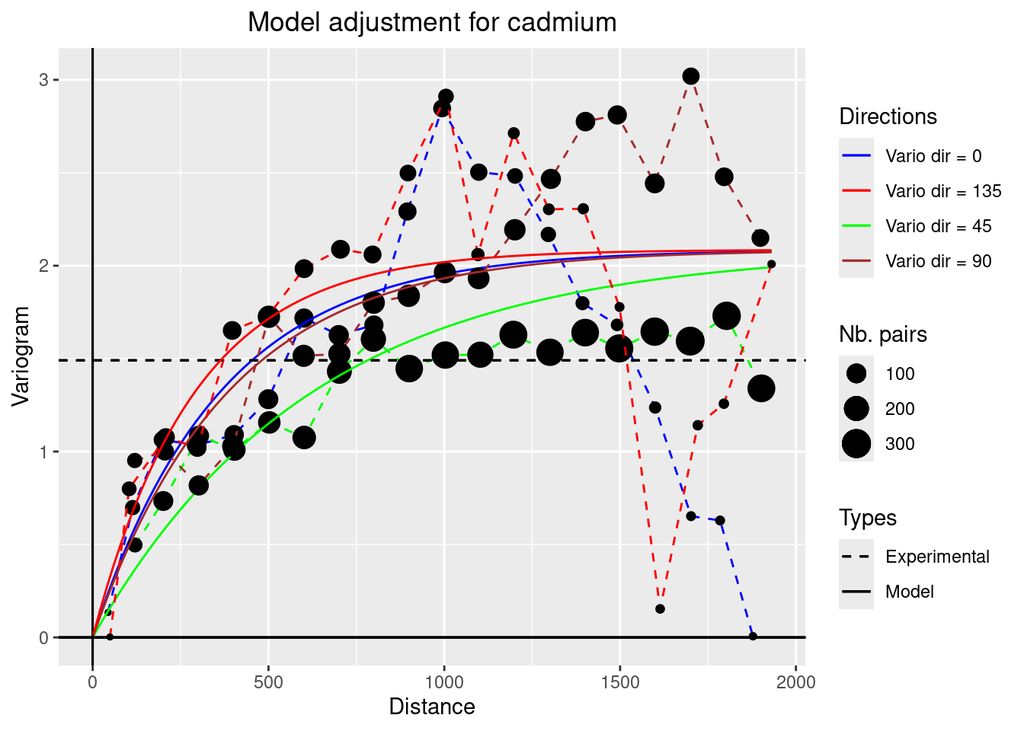

```r
# Plot of the experimental variogram and the fitted model
plot_vario(varioexp_aniso,model = model_aniso,pairDisplay = "size",
           title="Model adjustment for cadmium")
```

3. Compute a simple kriging prediction on the points in `targetDb` using the data in `obsDb` and the model `model_aniso` we just fitted. Plot the results (prediction and standard deviation of kriging error) and compare them to the results obtained with the model `model_iso`.

```r
## Simple kriging using gstlearn
minikriging(obsDb, targetDb, vname = "log_cadmium", model = model_aniso,
            type = "simple", prefix = "SK", mean = mean_log_cadmium,
            neighborhood = "unique", std = TRUE)
```

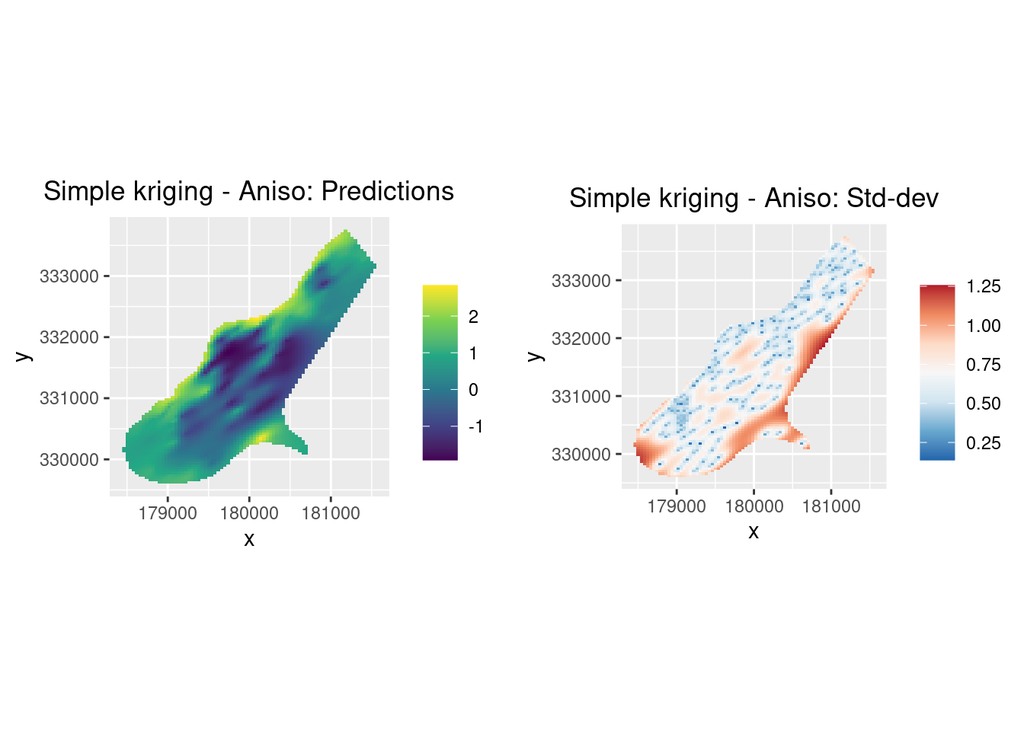

```r
## Plot the kriging predictions
p1=dbplot_grid(targetDb, color='SK.log_cadmium.estim',
               title='Simple kriging - Aniso: Predictions',legendTitle = "")

## Plot the kriging stdev
p2=dbplot_grid(targetDb, color='SK.log_cadmium.stdev',
               title='Simple kriging - Aniso: Std-dev',legendTitle = "", cmap="RdBu")

## Plot side-by-side
ggarrange(p1,p2,nrow=1)
```

Finally, to assess the quality of the predictions, let us perform a 1-fold cross-validation analysis. The idea is as follows: for each observation location $x_i$, we compute the kriging prediction at $x_i$ using all the observations except the one located at $x_i$. The cross-validation error at $x_i$ is then defined as the difference between this prediction and the actual observed value at $x_i$ and measures how far away from the real value the prediction is. A standardized cross-validation error can also be defined as the ratio of the cross-validation error at $x_i$ and the kriging standard deviation at $x_i$, to account from the error inherent to the kriging prediction.

4. Perform a cross-validation analysis on the simple kriging predictor defined in Question 3. Plot the histogram of cross-validation errors, and compute the mean cross-validation error, and the mean-squared cross-validation error. *(Hint: The function `minixvalid` allows to perform cross-validation analyses.)*

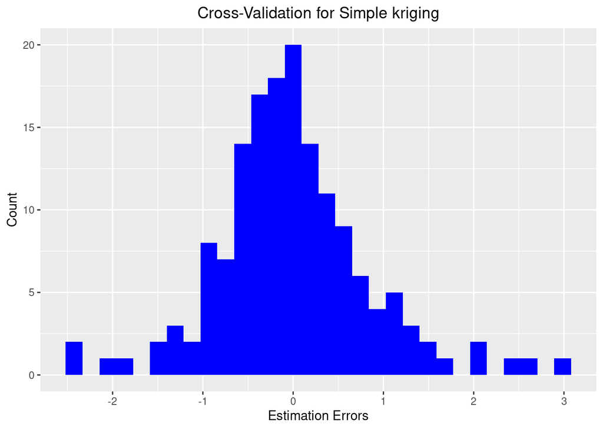

```r
## Cross-validation for simple kriging
minixvalid(obsDb, vname = "log_cadmium", model = model_aniso,
            type = "simple", prefix = "Xvalid_SK", mean = mean_log_cadmium,
            neighborhood = "unique", std = TRUE)

## Plot histogram errors
xvalid_name="Xvalid_SK.log_cadmium.esterr"
plot_hist(obsDb,vname=xvalid_name,nbin=30,color="blue",xlab="Estimation Errors", title="Cross-Validation for Simple kriging")
```

```r
## Print some statistics about the cross-validation errors
print(c("Mean cross-validation error:",mean(obsDb[xvalid_name], na.rm=TRUE)))
```

```
## [1] "Mean cross-validation error:" "-0.00668079122207252"
```

```r
print(c("Mean squared cross-validation error:",mean(obsDb[xvalid_name]^2, na.rm=TRUE)))
```

```
## [1] "Mean squared cross-validation error:"
## [2] "0.71009529991879"
```

```r
print(c("Mean squared standardized error:",mean(obsDb[xvalid_name]^2, na.rm=TRUE)))
```

```
## [1] "Mean squared standardized error:" "0.71009529991879"
```

Finally, we plot the cross-validation errors on a map.

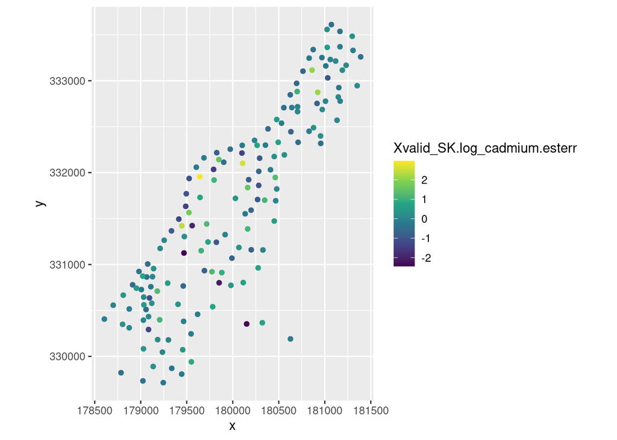

```r
dbplot_point(obsDb,color = "Xvalid_SK.log_cadmium.esterr", cmap="viridis")
```

## Ordinary kriging (Unique neighborhood)

Let us now perform an ordinary kriging prediction using the same model.

5. Using once again the `minikriging` function, compute an ordinary kriging prediction on the points in `targetDb` using the data in `obsDb` and the model `model_aniso`. Plot the results (prediction and standard deviation of kriging error) and compare them to the simple kriging prediction.

```r
minikriging(obsDb, targetDb, vname = "log_cadmium", model = model_aniso,
            type = "ordinary", prefix = "OK", neighborhood = "unique",
            std = TRUE)
```

Let us plot the results.

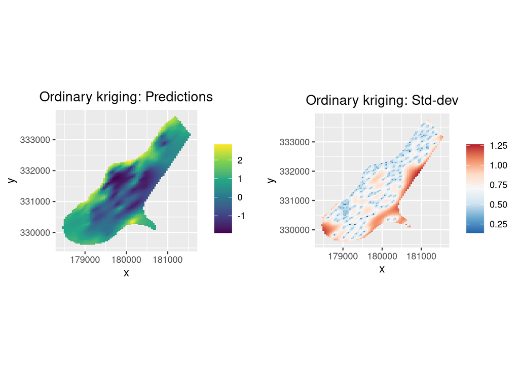

```r
## Plot kriging estimate
p1=dbplot_grid(targetDb, color='OK.log_cadmium.estim',
               title='Ordinary kriging: Predictions',legendTitle = "")

## Plot kriging stdev
p2=dbplot_grid(targetDb, color='OK.log_cadmium.stdev',
               title='Ordinary kriging: Std-dev',legendTitle = "", cmap="RdBu")

## Plot side-by-side
ggarrange(p1,p2,nrow=1)
```

6. Perform a cross-validation analysis on the resulting predictor.

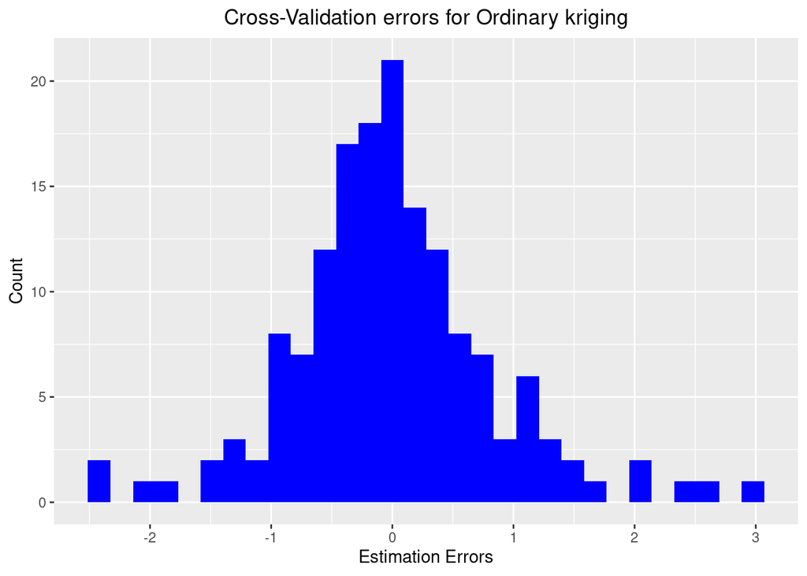

```r
## Cross-validation for ordinary kriging
minixvalid(obsDb, vname = "log_cadmium", model = model_aniso,
            type = "ordinary", prefix = "Xvalid_OK",
            neighborhood = "unique", std = TRUE)

## Plot histogram of errors
xvalid_name="Xvalid_OK.log_cadmium.esterr"
plot_hist(obsDb,vname=xvalid_name,nbin=30,color="blue",xlab="Estimation Errors", title="Cross-Validation errors for Ordinary kriging")
```

```r
## Print some statistics about the cross-validation errors
print(c("Mean cross-validation error:",mean(obsDb[xvalid_name], na.rm=TRUE)))
```

```
## [1] "Mean cross-validation error:" "0.00331996091204099"
```

```r
print(c("Mean squared cross-validation error:",mean(obsDb[xvalid_name]^2, na.rm=TRUE)))
```

```
## [1] "Mean squared cross-validation error:"
## [2] "0.707099287792792"
```

```r
print(c("Mean squared standardized error:",mean(obsDb[xvalid_name]^2, na.rm=TRUE)))
```

```
## [1] "Mean squared standardized error:" "0.707099287792792"
```

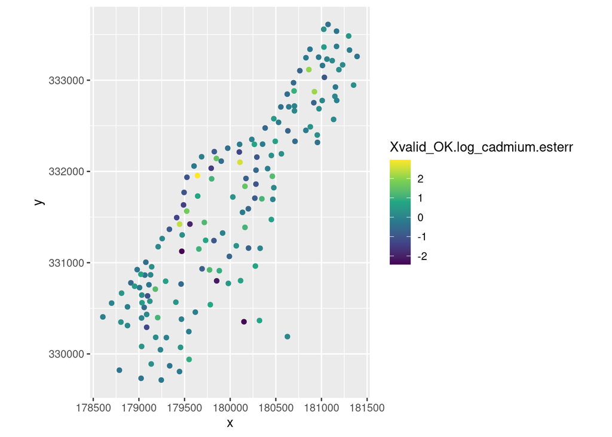

```r
## Plot map of cross-validation errors
dbplot_point(obsDb,color = xvalid_name, cmap="viridis")
```

Let us now compare the predictions obtained using simple and ordinary kriging. To do so, we use represent both predictors in a scatter-plot using the function `plot_scatter`.

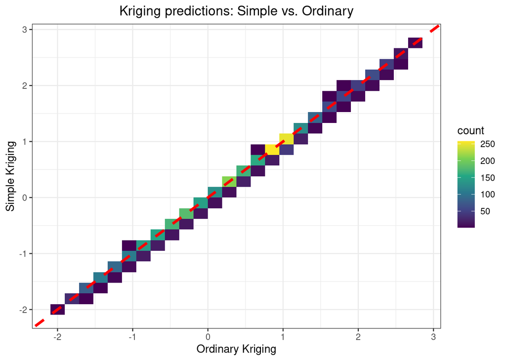

```r
## Scatter plot Simple Kriging VS Ordinary Kriging: Predictions
plot_scatter(targetDb,vnamex="OK.log_cadmium.estim",vnamey="SK.log_cadmium.estim",
              title="Kriging predictions: Simple vs. Ordinary", xlab="Ordinary Kriging", ylab="Simple Kriging",
             eqLine = TRUE)
```

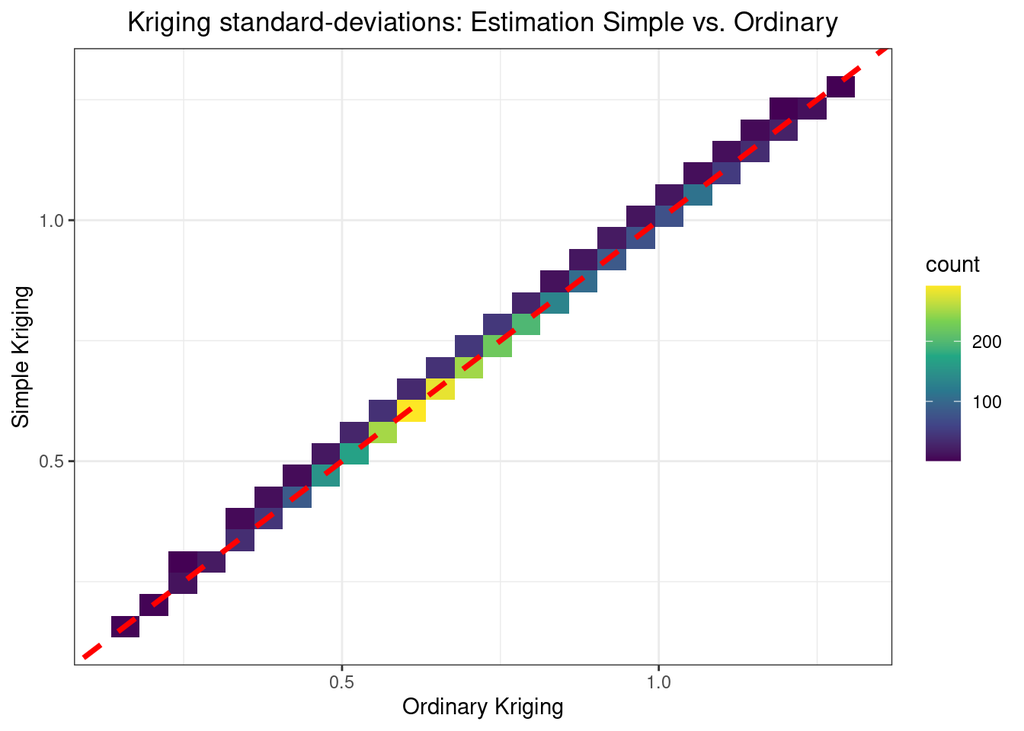

```r
## Scatter plot Simple Kriging VS Ordinary Kriging: Standard deviations
plot_scatter(targetDb,vnamex="OK.log_cadmium.stdev",vnamey="SK.log_cadmium.stdev",
              title="Kriging standard-deviations: Estimation Simple vs. Ordinary", xlab="Ordinary Kriging", ylab="Simple Kriging",
             eqLine = TRUE)
```

7. Compare the simple and ordinary kriging predictions and standard-deviations based on the cross-plots created above.

## Kriging with moving neighborhood

Up until now, we only considered kriging with a unique neighborhood. To work with a moving neighborhood, we first need to define it by creating “neighborhood” object describing its characteristics. This is done using the `neighborhood` parameter of the ‘kriging’ function, which expects a vector: `c(nmini, nmaxi, radius)` where * `radius` is a neighborhood radius * `nmini, nmaxi` are the minimum and maximum number of data points (within the specified neighborhood radius) that should be included in the neighborhood: for a given target point, if the number of data points within the neighborhood radius is smaller that the specified minimum, then no prediction is performed at this target (it is set to undefined). Note that it is also possible to set `neighborhood=radius` to use a neighborhood of radius `radius` without any restriction and the number of points it can contain, or to set `neighborhood=c(nmini, nmaxi)` to set a moving neighborhood containing between `nmini` and `nmaxi` points without any restriction of the radius.

```r
## Ordinary kriging
neigh=c(2,5,300)
minikriging(obsDb, targetDb, vname = "log_cadmium",
            model = model_aniso, type = "ordinary", prefix = "OK_mov",
            neighborhood = neigh,
            std = TRUE)
```

Let us plot the results we obtain.

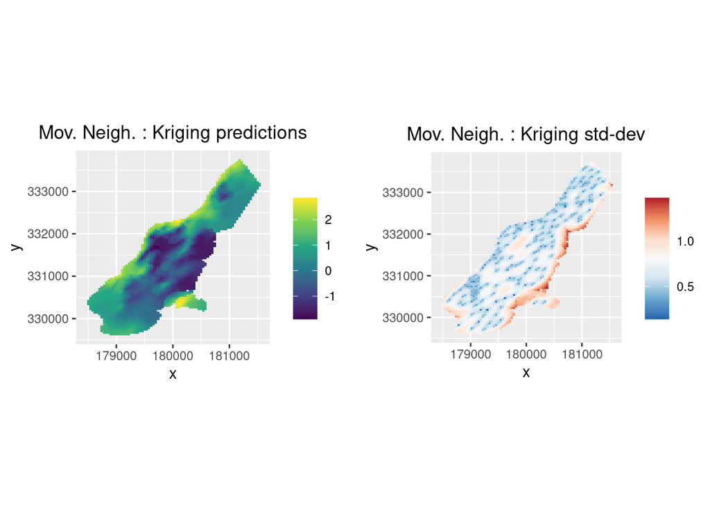

```r
## Plot of kriging predictions
p1 = dbplot_grid(targetDb, color='OK_mov.log_cadmium.estim',
                 title='Mov. Neigh. : Kriging predictions',legendTitle = "")

## Plot of kriging stdev
p2 = dbplot_grid(targetDb, color='OK_mov.log_cadmium.stdev',
                 title='Mov. Neigh. : Kriging std-dev',legendTitle = "", cmap = "RdBu")

## Plot side-by-side
ggarrange(p1,p2,nrow=1)
```

9. Comment the prediction maps obtained above.
10. Compare the results obtained with a unique neighborhood and a moving neighborhood (`OK` and `OK_mov`) visually, and using a cross-validation and a scatter plot.

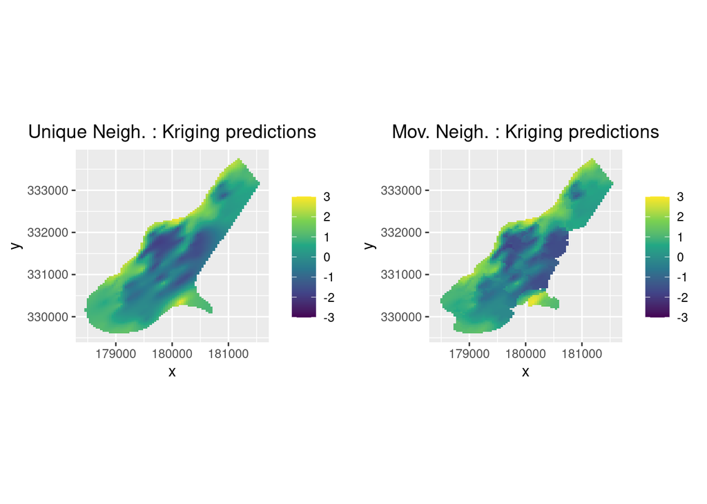

```r
## Common range of value for plotting
colValLimits = c(-3,3)

## Plot of kriging predictions using unique neighborhood
p1 = dbplot_grid(targetDb, color='OK.log_cadmium.estim',title='Unique Neigh. : Kriging predictions',legendTitle = "",colValLimits = colValLimits)

## Plot of kriging predictions using unique moving neighborhood
p2 = dbplot_grid(targetDb, color='OK_mov.log_cadmium.estim',title='Mov. Neigh. : Kriging predictions',legendTitle = "",colValLimits = colValLimits)

## Plot side-by-side
ggarrange(p1,p2,nrow=1)
```

```r
## Cross-validation for Ordinary kriging with moving neigborhood (Use the prefix "Xvalid_OK_mov")
minixvalid(obsDb, vname = "log_cadmium", model=model_aniso, type = "ordinary", prefix="Xvalid_OK_mov", mean = mean_log_cadmium, neighborhood = "unique", std = TRUE)
```

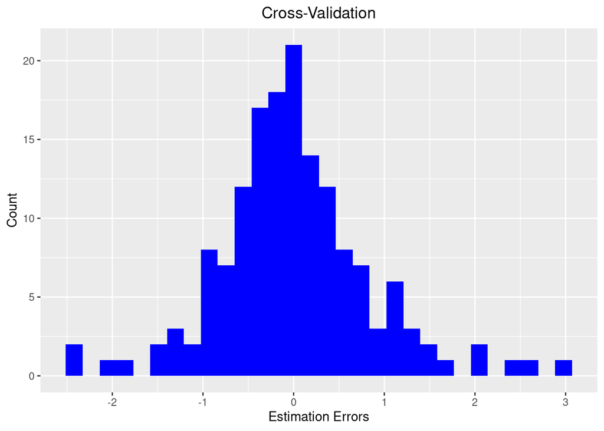

```r
xvalid_name="Xvalid_OK_mov.log_cadmium.esterr"
## Plot Histogram of cross-validation error
plot_hist(obsDb,vname=xvalid_name,nbin=30,color="blue",xlab="Estimation Errors", title="Cross-Validation")
```

```r
## Print some statistics about the cross-validation errors
print(c("Mean cross-validation error:",mean(obsDb[,xvalid_name], na.rm=TRUE)))
```

```
## [1] "Mean cross-validation error:" "0.00331996091204099"
```

```r
print(c("Mean squared cross-validation error:",mean(obsDb[,xvalid_name]^2, na.rm=TRUE)))
```

```
## [1] "Mean squared cross-validation error:"
## [2] "0.707099287792792"
```

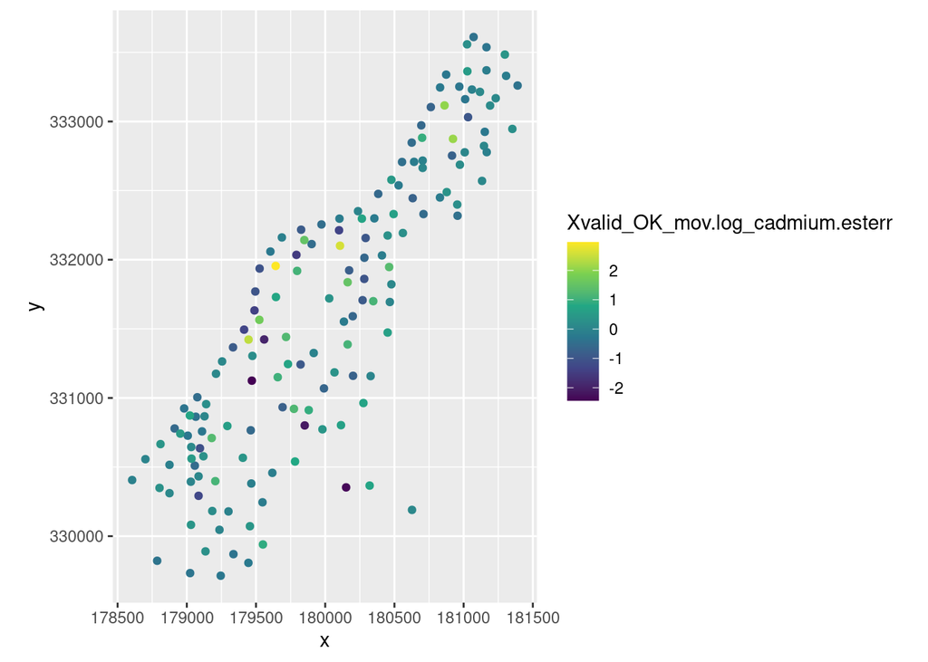

```r
## Plot ordinary kriging prediction and
dbplot_point(obsDb,color = xvalid_name, cmap="viridis")
```

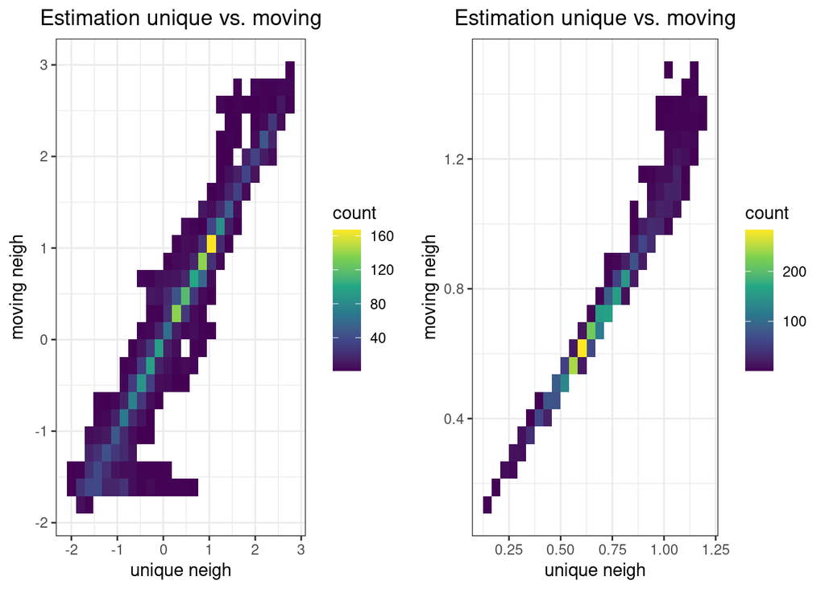

```r
## Scatter plot Ordinary Kriging unique neigborhood VS moving neigborhood: Predictions
p1=plot_scatter(targetDb,vnamex="OK.log_cadmium.estim",vnamey="OK_mov.log_cadmium.estim",
                title="Estimation unique vs. moving", xlab="unique neigh", ylab="moving neigh")

## Scatter plot Simple Kriging VS Ordinary Kriging: Standard deviations
p2=plot_scatter(targetDb,vnamex="OK.log_cadmium.stdev",vnamey="OK_mov.log_cadmium.stdev",
               title="Estimation unique vs. moving", xlab="unique neigh", ylab="moving neigh")

## Plot side by side
print(ggarrange(p1,p2,nrow=1))
```

Bonus question: try with other neighborhoods and compare the results.

## Change of model

Change the models (impose other structures) and compare the performance of kriging estimates (be attentive to the changes in standard deviation of kriging error).

```r
## Define model
struct_names=c("NUGGET","EXPONENTIAL")
# fitting the model
model_aniso=model_fit(varioexp_aniso,struct=struct_names)
# display of the model
model_aniso$display() ## look at the anisotropic matrices
```

```
##
## Model characteristics
## =====================
## Space dimension              = 2
## Number of variable(s)        = 1
## Number of basic structure(s) = 2
## Number of drift function(s)  = 0
## Number of drift equation(s)  = 0
##
## Covariance Part
## ---------------
## Nugget Effect
## - Sill         =      0.562
## Exponential
## - Sill         =      2.999
## - Ranges       =   8878.667  3402.377
## - Theo. Ranges =   2963.772  1135.741
## - Angles       =     47.176     0.000
## - Rotation Matrix
##                [,  0]    [,  1]
##      [  0,]    -0.680     0.733
##      [  1,]    -0.733    -0.680
## Total Sill     =      3.561
## Known Mean(s)     0.000
```

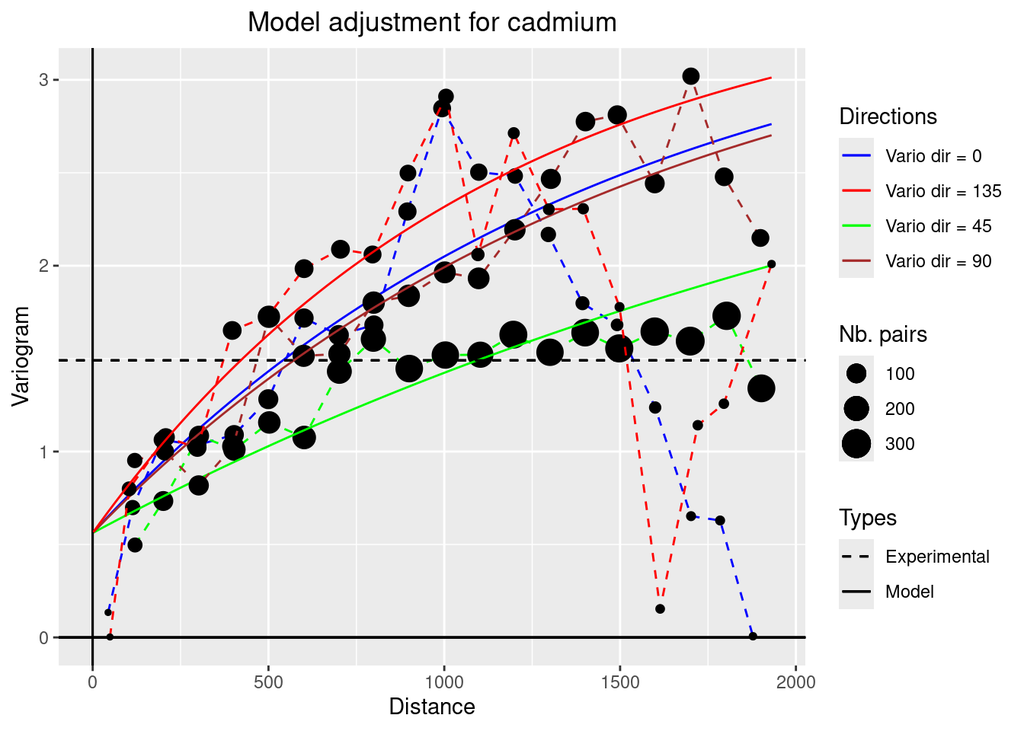

```r
# plot of the experiment variogram and the fitted model
plot_vario(varioexp_aniso,model = model_aniso,pairDisplay = "size",
           title="Model adjustment for cadmium")
```

```r
## ....
```

# Multivariate geostatistics

We now illustrate how to perform multivariate predictions using `gstlearn`. Our goal will be to jointly predict the log-concentraton of the 4 heavy metals in the Db `obsDb` (namely cadmium, copper, lead and zinc) using a multivariate geostatistical model.

We start by fitting a multivariate variogram model on the metal log-concentrations data in `obsDat`. As in the previous practical session, this is done in 2 steps: we start by computing experimiental variograms and cross-variograms and then fit them with a finite set of basic structures (here an exponential covariance and a nugget effect). We end up with a multivariate model `model_aniso4var`.

```r
# Variable names
variable_names=paste0("log_", c("cadmium","copper","lead","zinc"))

# Directional variograms and cross variograms
vario_aniso4var = vario_exp(obsDb,vname=variable_names,dir=c(0,45,90,135),nlag=20, dlag=100.)

## Auto-fit
struct_names = c("NUGGET","EXPONENTIAL")
model_aniso4var=model_fit(vario_aniso4var,struct=struct_names)

# Display and plot
model_aniso4var$display()
```

```
##
## Model characteristics
## =====================
## Space dimension              = 2
## Number of variable(s)        = 4
## Number of basic structure(s) = 2
## Number of drift function(s)  = 0
## Number of drift equation(s)  = 0
##
## Covariance Part
## ---------------
## Nugget Effect
## - Sill matrix:
##                [,  0]    [,  1]    [,  2]    [,  3]
##      [  0,]     0.516     0.120     0.073     0.111
##      [  1,]     0.120     0.071     0.026     0.042
##      [  2,]     0.073     0.026     0.047     0.038
##      [  3,]     0.111     0.042     0.038     0.050
## Exponential
## - Sill matrix:
##                [,  0]    [,  1]    [,  2]    [,  3]
##      [  0,]     2.336     0.964     1.446     1.600
##      [  1,]     0.964     0.441     0.638     0.707
##      [  2,]     1.446     0.638     0.974     1.048
##      [  3,]     1.600     0.707     1.048     1.151
## - Ranges       =   2021.422  8167.377
## - Theo. Ranges =    674.767  2726.338
## - Angles       =    140.632     0.000
## - Rotation Matrix
##                [,  0]    [,  1]
##      [  0,]     0.773     0.634
##      [  1,]    -0.634     0.773
## Total Sill
##                [,  0]    [,  1]    [,  2]    [,  3]
##      [  0,]     2.851     1.084     1.519     1.711
##      [  1,]     1.084     0.512     0.665     0.749
##      [  2,]     1.519     0.665     1.020     1.086
##      [  3,]     1.711     0.749     1.086     1.202
##
## Known Mean(s)     0.000     0.000     0.000     0.000
```

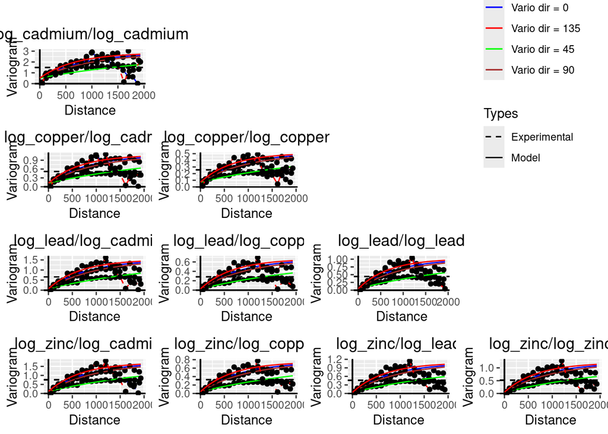

```r
plot_vario(vario_aniso4var, model_aniso4var)
```

Computing co-kriging predictions is done using once again the `minikriging` function. The call to this function is the same as in the univariate case. The only difference is that now, a vector of variables names must be supplied to the `vname` argument and the model supplied in `model` must then be a multivariate model.

If such arguments are supplied to the `minikriging` function, then it computes the cokriging predictions for each variable in `vname` using the model `model`.

```r
minikriging(obsDb, targetDb, vname = variable_names, model = model_aniso4var,
            type = "ordinary", prefix = "COK", neighborhood = "unique",
            std = TRUE)
```

Let us plot the results

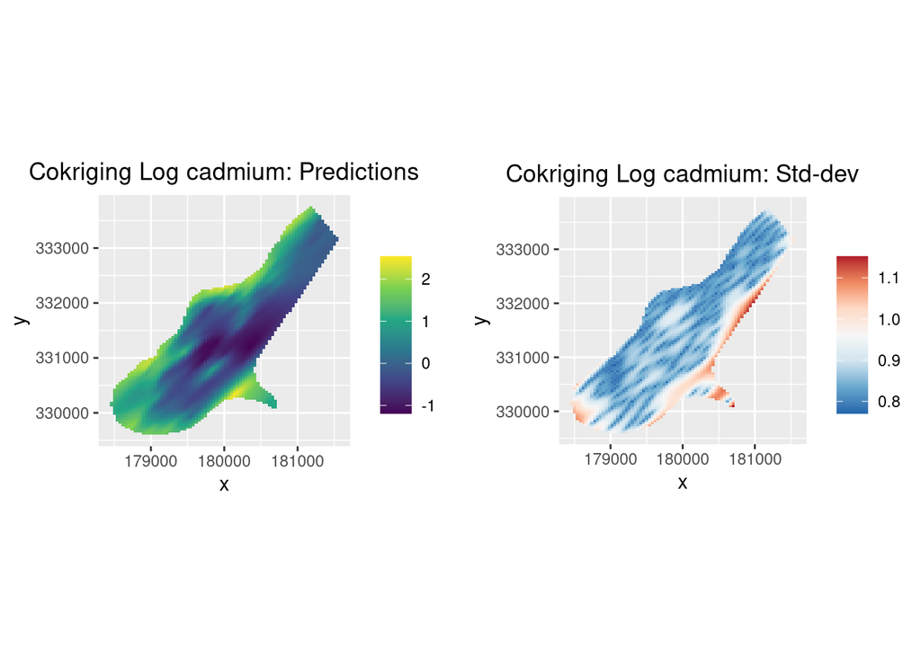

```r
## Cokriging prediction of Cadmium
p1=dbplot_grid(targetDb,color = 'COK.log_cadmium.estim',
               title='Cokriging Log cadmium: Predictions',legendTitle = "")
## Cokriging standard deviation of Cadmium
p2=dbplot_grid(targetDb,color = 'COK.log_cadmium.stdev',
               title='Cokriging Log cadmium: Std-dev',legendTitle = "", cmap="RdBu")
## Plot side by side
ggarrange(p1,p2,nrow = 1)
```

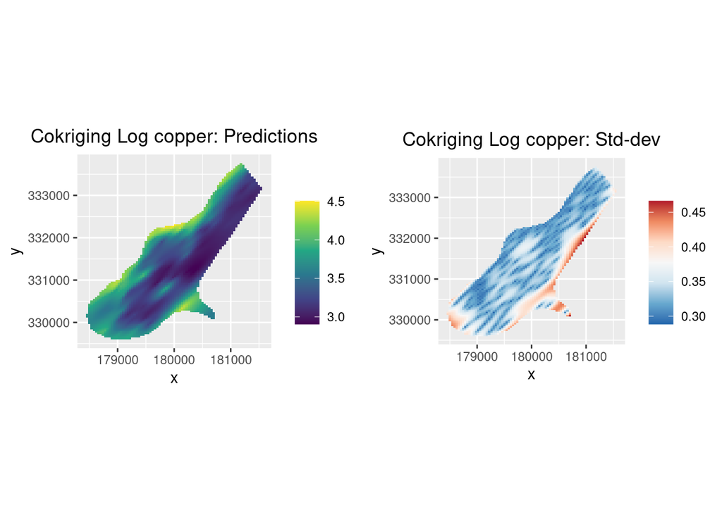

```r
## Cokriging prediction of Copper
p1=dbplot_grid(targetDb,color = 'COK.log_copper.estim',
               title='Cokriging Log copper: Predictions',legendTitle = "")
## Cokriging standard deviation of copper
p2=dbplot_grid(targetDb,color = 'COK.log_copper.stdev',
               title='Cokriging Log copper: Std-dev',legendTitle = "", cmap="RdBu")
## Plot side by side
ggarrange(p1,p2,nrow = 1)
```

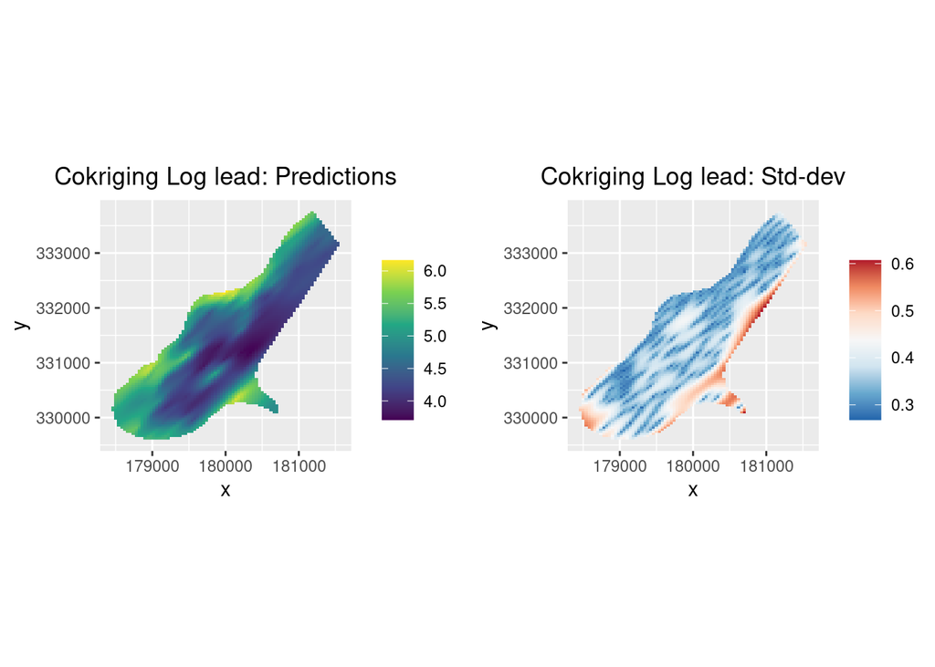

```r
## Cokriging prediction of Lead
p1=dbplot_grid(targetDb,color = 'COK.log_lead.estim',
               title='Cokriging Log lead: Predictions',legendTitle = "")
## Cokriging standard deviation of lead
p2=dbplot_grid(targetDb,color = 'COK.log_lead.stdev',
               title='Cokriging Log lead: Std-dev',legendTitle = "", cmap="RdBu")
## Plot side by side
ggarrange(p1,p2,nrow = 1)
```

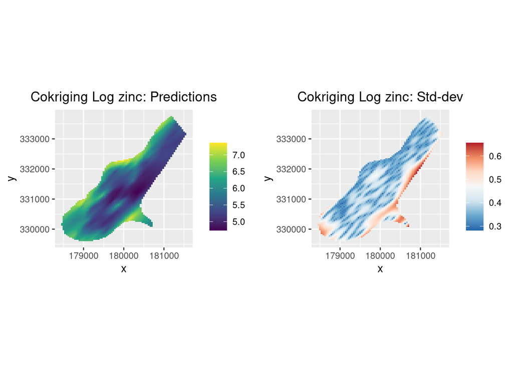

```r
## Cokriging prediction of Zinc
p1=dbplot_grid(targetDb,color = 'COK.log_zinc.estim',
               title='Cokriging Log zinc: Predictions',legendTitle = "")
## Cokriging standard deviation of zinc
p2=dbplot_grid(targetDb,color = 'COK.log_zinc.stdev',
               title='Cokriging Log zinc: Std-dev',legendTitle = "", cmap="RdBu")
## Plot side by side
ggarrange(p1,p2,nrow = 1)
```

## Comparaison OK / CoKriging

3. Compare ordinary kriging and cokriging results

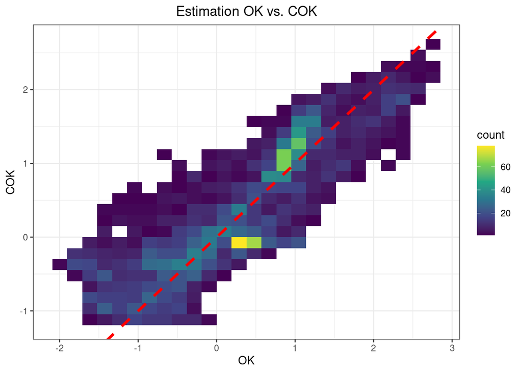

```r
## Scatter plot CoKriging VS Ordinary Kriging: Predictions

plot_scatter(targetDb,vnamex="OK.log_cadmium.estim",vnamey="COK.log_cadmium.estim", title="Estimation OK vs. COK",
                    xlab="OK", ylab="COK",eqLine=TRUE)
```

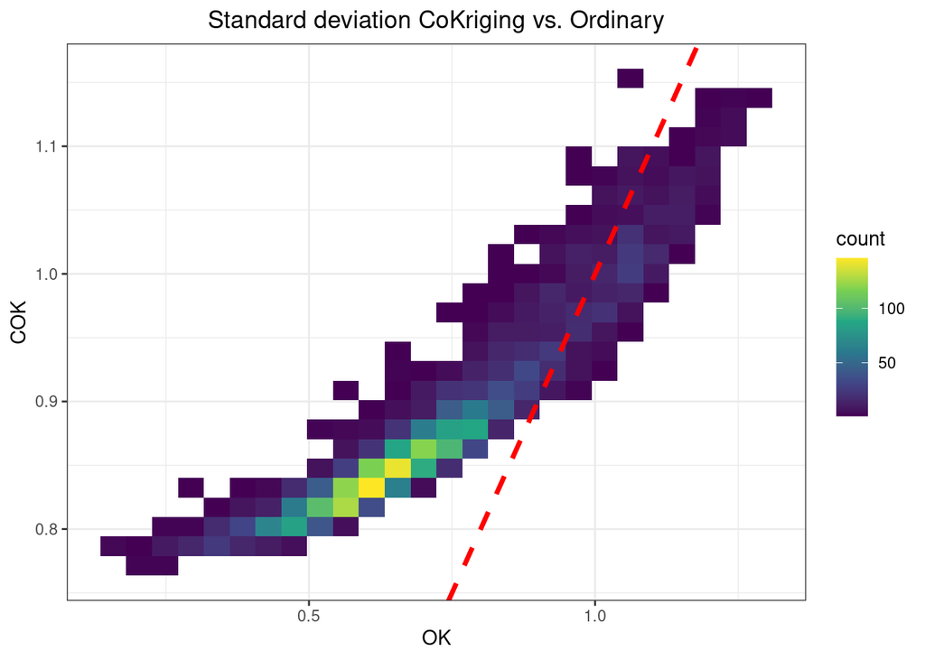

```r
## Scatter plot CoKriging VS Ordinary Kriging: Standard deviations
plot_scatter(targetDb,vnamex="OK.log_cadmium.stdev",vnamey="COK.log_cadmium.stdev", title="Standard deviation CoKriging vs. Ordinary",
                    xlab="OK", ylab="COK",eqLine=TRUE)
```